# Lab #2

Author

Erik Whitfield

Published

August 30, 2025

# Exploring Data Through Frequencies

## Introduction

Understanding the distribution of data is fundamental to statistical analysis. In this lab, we want to learn how to create frequency tables, calculate cumulative frequencies, and visualize distributions using bar plots and histograms. We’ll work with the built-in `mtcars` dataset, which contains information about 32 automobiles from a 1974 Motor Trend magazine.

Let’s begin by examining our dataset:

```r
# Load and examine the mtcars dataset
data(mtcars)
head(mtcars)
```

```
                   mpg cyl disp  hp drat    wt  qsec vs am gear carb
Mazda RX4         21.0   6  160 110 3.90 2.620 16.46  0  1    4    4
Mazda RX4 Wag     21.0   6  160 110 3.90 2.875 17.02  0  1    4    4
Datsun 710        22.8   4  108  93 3.85 2.320 18.61  1  1    4    1
Hornet 4 Drive    21.4   6  258 110 3.08 3.215 19.44  1  0    3    1
Hornet Sportabout 18.7   8  360 175 3.15 3.440 17.02  0  0    3    2
Valiant           18.1   6  225 105 2.76 3.460 20.22  1  0    3    1
```

```r
str(mtcars)
```

```
'data.frame':   32 obs. of  11 variables:
 $ mpg : num  21 21 22.8 21.4 18.7 18.1 14.3 24.4 22.8 19.2 ...
 $ cyl : num  6 6 4 6 8 6 8 4 4 6 ...
 $ disp: num  160 160 108 258 360 ...
 $ hp  : num  110 110 93 110 175 105 245 62 95 123 ...
 $ drat: num  3.9 3.9 3.85 3.08 3.15 2.76 3.21 3.69 3.92 3.92 ...
 $ wt  : num  2.62 2.88 2.32 3.21 3.44 ...
 $ qsec: num  16.5 17 18.6 19.4 17 ...
 $ vs  : num  0 0 1 1 0 1 0 1 1 1 ...
 $ am  : num  1 1 1 0 0 0 0 0 0 0 ...
 $ gear: num  4 4 4 3 3 3 3 4 4 4 ...
 $ carb: num  4 4 1 1 2 1 4 2 2 4 ...
```

## Frequency Tables

### Basic Frequency Tables

The `table()` function is your primary tool for creating frequency tables in R. It counts the occurrences of each unique value in a vector.

```r
# Create a frequency table for number of cylinders
cyl_freq <- table(mtcars$cyl)
cyl_freq
```

```
 4  6  8
11  7 14
```

### Frequency Tables with Proportions

To convert frequencies to proportions (relative frequencies), use the `prop.table()` function:

```r
# Calculate proportions
cyl_prop <- prop.table(cyl_freq)
cyl_prop
```

```
      4       6       8
0.34375 0.21875 0.43750
```

```r
# Convert to percentages
cyl_percent <- prop.table(cyl_freq) * 100
cyl_percent
```

```
     4      6      8
34.375 21.875 43.750
```

### Cumulative Frequencies

Cumulative frequencies show the running total of frequencies up to each category. Use the `cumsum()` function:

```r
# Calculate cumulative frequencies
cyl_cumfreq <- cumsum(cyl_freq)
cyl_cumfreq
```

```
 4  6  8
11 18 32
```

```r
# Create a comprehensive frequency table
freq_table <- data.frame(
  Cylinders       = names(cyl_freq),
  Frequency       = as.numeric(cyl_freq),
  Proportion      = as.numeric(cyl_prop),
  Percentage      = as.numeric(cyl_percent),
  Cumulative_Freq = as.numeric(cyl_cumfreq),
  Cumulative_Prop = cumsum(as.numeric(cyl_prop))
)
freq_table
```

```
  Cylinders Frequency Proportion Percentage Cumulative_Freq Cumulative_Prop
1         4        11    0.34375     34.375              11         0.34375
2         6         7    0.21875     21.875              18         0.56250
3         8        14    0.43750     43.750              32         1.00000
```

## Bar Plots

### Basic Bar Plots

The `barplot()` function creates bar charts from frequency tables or vectors:

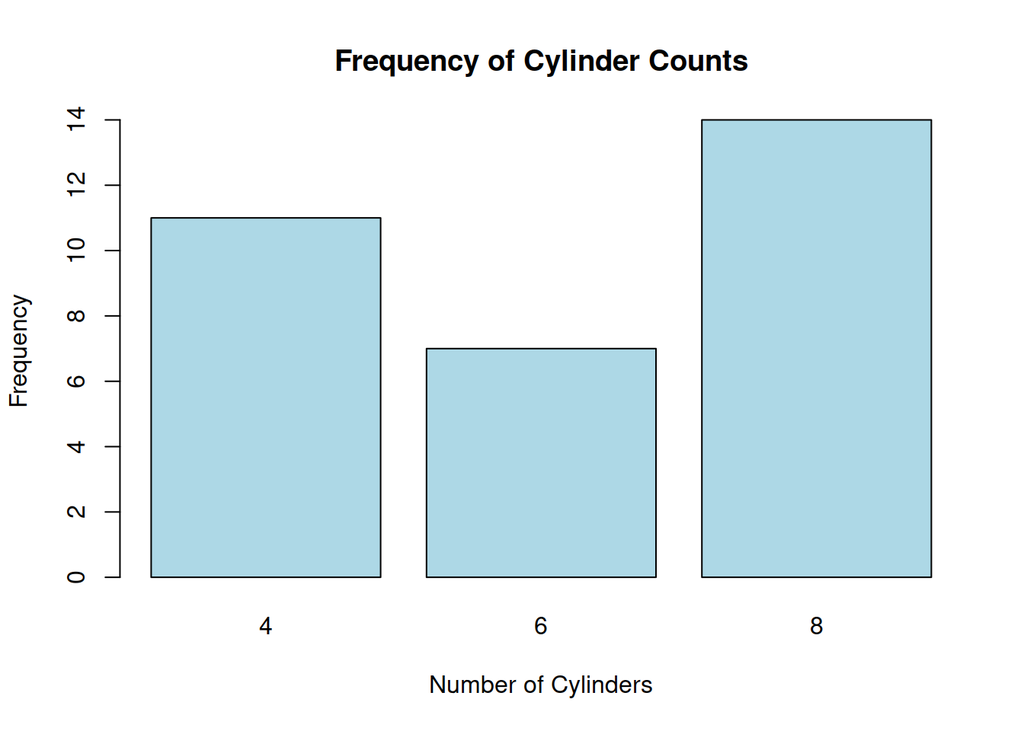

```r
# Basic bar plot of cylinder frequencies
barplot(
  cyl_freq,
  main   = "Frequency of Cylinder Counts",
  xlab   = "Number of Cylinders",
  ylab   = "Frequency",
  col    = "lightblue",
  border = "black"
)
```

### Customizing Bar Plots

You can enhance your bar plots with various arguments:

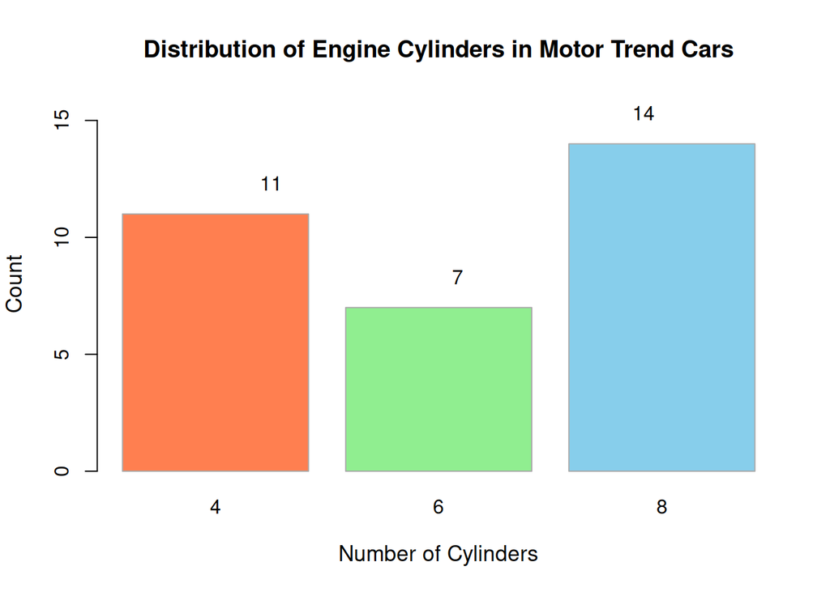

```r
# Enhanced bar plot
barplot(
  cyl_freq,
  main     = "Distribution of Engine Cylinders in Motor Trend Cars",
  xlab     = "Number of Cylinders",
  ylab     = "Count",
  col      = c("coral", "lightgreen", "skyblue"),
  border   = "darkgray",
  ylim     = c(0, max(cyl_freq) + 2),
  cex.main = 1.2,
  cex.lab  = 1.1
)

# Add value labels on top of bars
text(
  x = seq_along(cyl_freq),
  y = cyl_freq + 0.5,
  labels = cyl_freq,
  pos = 3
)
```

### Horizontal Bar Plots

Sometimes horizontal orientation improves readability:

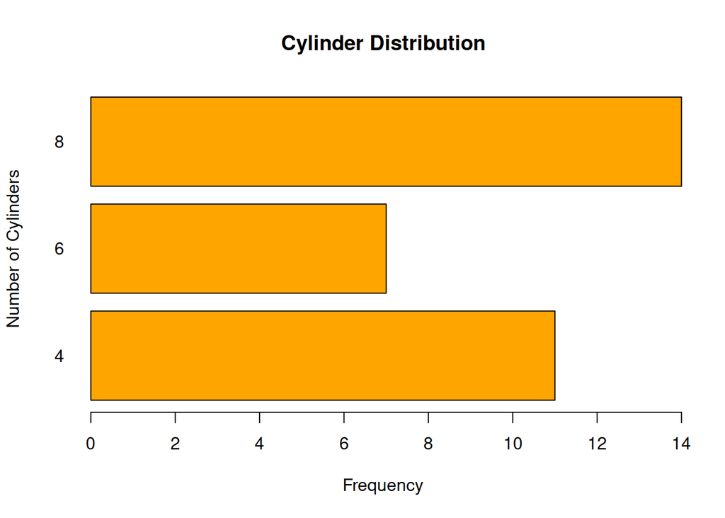

```r
# Horizontal bar plot
barplot(cyl_freq,
        main = "Cylinder Distribution",
        xlab = "Frequency",
        ylab = "Number of Cylinders",
        col = "orange",
        horiz = TRUE,
        las = 1)  # las=1 makes y-axis labels horizontal
```

## Histograms

### Basic Histograms

Histograms display the distribution of continuous variables by grouping values into bins. The `hist()` function is your tool of choice:

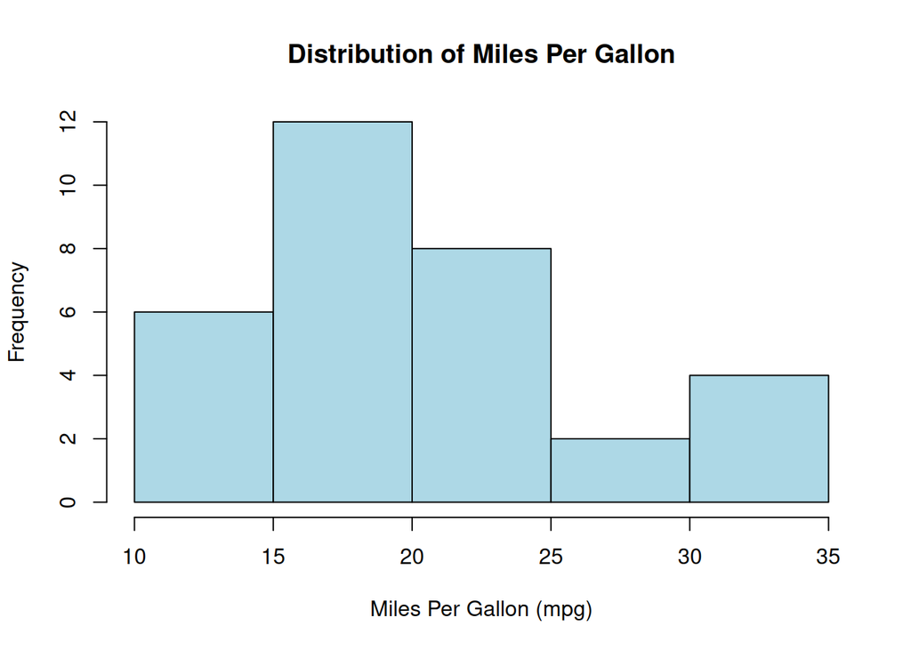

```r
# Basic histogram of miles per gallon
hist(
  mtcars$mpg,
  main = "Distribution of Miles Per Gallon",
  xlab = "Miles Per Gallon (mpg)",
  ylab = "Frequency",
  col = "lightblue",
  border = "black"
)
```

### Controlling Bin Width and Number

You can control the histogram appearance using the `breaks` argument:

[figure not shown]

```r
# Histogram with specific number of bins
hist(
  mtcars$mpg,
  breaks = 8,
  main = "MPG Distribution (8 bins)",
  xlab = "Miles Per Gallon",
  ylab = "Frequency",
  col = "palegreen",
  border = "darkgreen"
)
```

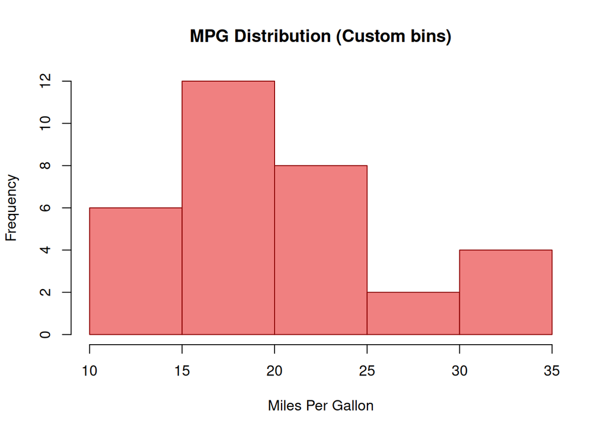

```r
# Histogram with specific break points
hist(
  mtcars$mpg,
  breaks = c(10, 15, 20, 25, 30, 35),
  main = "MPG Distribution (Custom bins)",
  xlab = "Miles Per Gallon",
  ylab = "Frequency",
  col = "lightcoral",
  border = "darkred"
)
```

### Density Histograms

Convert frequencies to densities for better comparison across datasets:

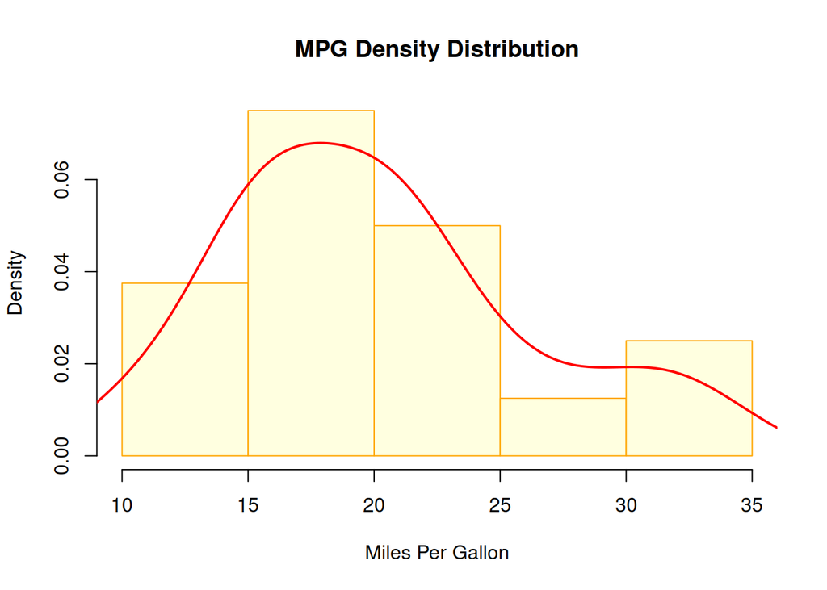

```r
# Density histogram
hist(
  mtcars$mpg,
  freq   = FALSE,  # This creates a density histogram
  main   = "MPG Density Distribution",
  xlab   = "Miles Per Gallon",
  ylab   = "Density",
  col    = "lightyellow",
  border = "orange"
)

# Add a density curve
lines(density(mtcars$mpg), col = "red", lwd = 2)
```

### Multiple Histograms for Comparison

You can create side-by-side histograms to compare distributions:

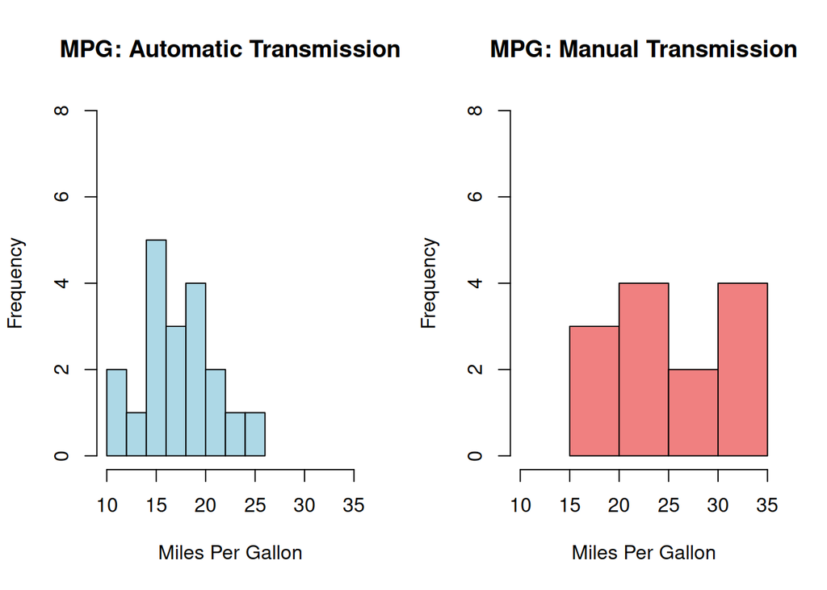

```r
# Set up plotting area for multiple plots
par(mfrow = c(1, 2))

# Histogram for automatic transmission cars
auto_mpg <- mtcars$mpg[mtcars$am == 0]
hist(auto_mpg,
     main = "MPG: Automatic Transmission",
     xlab = "Miles Per Gallon",
     ylab = "Frequency",
     col = "lightblue",
     xlim = c(10, 35),
     ylim = c(0, 8))

# Histogram for manual transmission cars
manual_mpg <- mtcars$mpg[mtcars$am == 1]
hist(manual_mpg,
     main = "MPG: Manual Transmission",
     xlab = "Miles Per Gallon",
     ylab = "Frequency",
     col = "lightcoral",
     xlim = c(10, 35),
     ylim = c(0, 8))
```

```r
# Reset plotting parameters
par(mfrow = c(1, 1))
```

## Advanced Techniques

### Creating Frequency Tables for Continuous Data

For continuous variables, you’ll need to create bins first:

```r
# Create bins for miles per gallon
mpg_bins <- cut(mtcars$mpg,
                breaks = c(10, 15, 20, 25, 30, 35),
                labels = c("10-15", "15-20", "20-25", "25-30", "30-35"),
                include.lowest = TRUE)

# Create frequency table
mpg_freq <- table(mpg_bins)
mpg_freq
```

```
mpg_bins
10-15 15-20 20-25 25-30 30-35
    6    12     8     2     4
```

```r
# Calculate cumulative frequencies
mpg_cumfreq <- cumsum(mpg_freq)
mpg_cumfreq
```

```
10-15 15-20 20-25 25-30 30-35
    6    18    26    28    32
```

### Comprehensive Frequency Analysis

Let’s put it all together with a complete analysis:

```r
# Complete frequency analysis for cylinder data
cat("=== FREQUENCY ANALYSIS: ENGINE CYLINDERS ===\n\n")
```

```
=== FREQUENCY ANALYSIS: ENGINE CYLINDERS ===
```

```r
# Basic frequency table
freq <- table(mtcars$cyl)
cat("Frequency Table:\n")
```

```
Frequency Table:
```

```r
print(freq)
```

```
 4  6  8
11  7 14
```

```r
cat("\nProportion Table:\n")
```

```
Proportion Table:
```

```r
prop <- prop.table(freq)
print(round(prop, 3))
```

```
    4     6     8
0.344 0.219 0.438
```

```r
cat("\nPercentage Table:\n")
```

```
Percentage Table:
```

```r
percent <- prop.table(freq) * 100
print(round(percent, 1))
```

```
   4    6    8
34.4 21.9 43.8
```

```r
cat("\nCumulative Frequencies:\n")
```

```
Cumulative Frequencies:
```

```r
cumfreq <- cumsum(freq)
print(cumfreq)
```

```
 4  6  8
11 18 32
```

```r
cat("\nCumulative Proportions:\n")
```

```
Cumulative Proportions:
```

```r
cumprop <- cumsum(prop)
print(round(cumprop, 3))
```

```
    4     6     8
0.344 0.562 1.000
```

### Saving Frequency Information

You can extract histogram information for further analysis:

```r
# Store histogram information
mpg_hist <- hist(mtcars$mpg, plot = FALSE)

# Examine the structure
str(mpg_hist)
```

```
List of 6
 $ breaks  : int [1:6] 10 15 20 25 30 35
 $ counts  : int [1:5] 6 12 8 2 4
 $ density : num [1:5] 0.0375 0.075 0.05 0.0125 0.025
 $ mids    : num [1:5] 12.5 17.5 22.5 27.5 32.5
 $ xname   : chr "mtcars$mpg"
 $ equidist: logi TRUE
 - attr(*, "class")= chr "histogram"
```

```r
# Access specific components
cat("Bin breaks:", mpg_hist$breaks, "\n")
```

```
Bin breaks: 10 15 20 25 30 35
```

```r
cat("Bin counts:", mpg_hist$counts, "\n")
```

```
Bin counts: 6 12 8 2 4
```

```r
cat("Bin midpoints:", mpg_hist$mids, "\n")
```

```
Bin midpoints: 12.5 17.5 22.5 27.5 32.5
```

## Practical Applications

### Quality Control Example

Let’s use our techniques to analyze car performance:

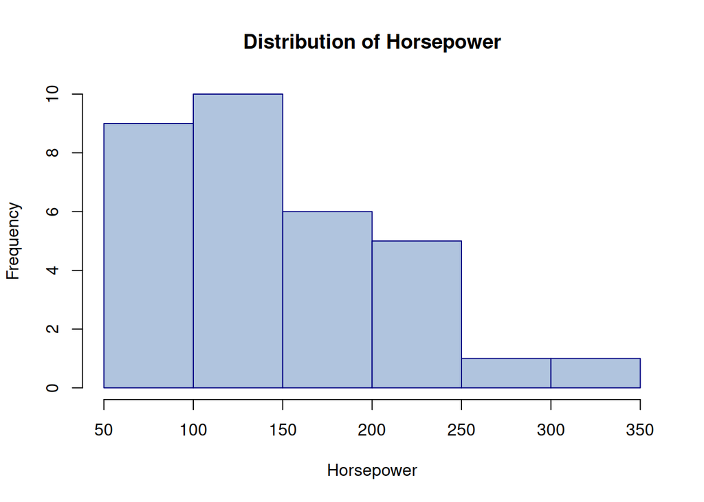

```r
# Analyze the distribution of horsepower
hp_hist <- hist(mtcars$hp,
                breaks = 10,
                main = "Distribution of Horsepower",
                xlab = "Horsepower",
                ylab = "Frequency",
                col = "lightsteelblue",
                border = "navy")
```

```r
# Identify cars with unusual horsepower
mean_hp <- mean(mtcars$hp)
sd_hp <- sd(mtcars$hp)

# Cars with horsepower more than 2 standard deviations from mean
unusual_cars <- subset(mtcars, abs(hp - mean_hp) > 2 * sd_hp)
cat("Cars with unusual horsepower:\n")
```

```
Cars with unusual horsepower:
```

```r
print(row.names(unusual_cars))
```

```
[1] "Maserati Bora"
```

### Creating Publication-Ready Tables

```r
# Create a formatted frequency table
gear_analysis <- function(x) {
  freq <- table(x)
  prop <- prop.table(freq)
  cumfreq <- cumsum(freq)
  cumprop <- cumsum(prop)

  result <- data.frame(
    Value = names(freq),
    Frequency = as.numeric(freq),
    Proportion = round(as.numeric(prop), 3),
    Percentage = round(as.numeric(prop * 100), 1),
    Cum_Frequency = as.numeric(cumfreq),
    Cum_Proportion = round(as.numeric(cumprop), 3)
  )
  return(result)
}

# Apply to gear data
gear_table <- gear_analysis(mtcars$gear)
cat("Frequency Analysis: Number of Forward Gears\n")
```

```
Frequency Analysis: Number of Forward Gears
```

```r
print(gear_table)
```

```
  Value Frequency Proportion Percentage Cum_Frequency Cum_Proportion
1     3        15      0.469       46.9            15          0.469
2     4        12      0.375       37.5            27          0.844
3     5         5      0.156       15.6            32          1.000
```

## Exercise Problems

**Exercise 1**: Create a frequency table for the `carb` variable (number of carburetors) in the `mtcars` dataset. Calculate both frequencies and percentages.

**Exercise 2**: Create a histogram of the `wt` variable (weight) with 6 bins. Add appropriate titles and labels.

**Exercise 3**: Create a grouped bar plot showing the relationship between `gear` (number of gears) and `cyl` (number of cylinders).

**Exercise 4**: Using the `airquality` dataset, create a frequency table for the `Month` variable and calculate cumulative frequencies.

## Key Points to Remember

When working with frequency analysis in R, keep these essential points in mind:

- Use `table()` for creating frequency tables from categorical data
- Apply `prop.table()` to convert frequencies to proportions
- Employ `cumsum()` to calculate cumulative frequencies
- Use `barplot()` for categorical data visualization
- Use `hist()` for continuous data visualization
- The `breaks` argument in `hist()` controls bin specification
- Always add meaningful titles and axis labels to your plots
- Consider your audience when choosing between frequencies, proportions, or percentages

The combination of frequency tables and visual displays provides a powerful foundation for understanding your data’s distribution and identifying patterns that merit further investigation.

## Summary

In this lesson, you learned to create comprehensive frequency analyses using base R functions. You can now construct frequency tables with cumulative frequencies, create informative bar plots for categorical data, and build histograms to visualize continuous distributions. These fundamental skills form the backbone of exploratory data analysis and will serve you well as you progress to more advanced statistical techniques.

Remember that the choice between different visualization methods depends on your data type: use bar plots for categorical variables and histograms for continuous variables. Always consider your audience and the story your data tells when selecting appropriate frequency measures and visual displays.